# Lab5

Ali Haydar Ozgun

10/11/2021

Problem 1; Trust but verify. We trust that the rnorm() will generate random deviates in accordance with the definition of the normal distribution. For example, we learned in this lab, that a normal distribution with mean = 0, and sd =1 , should only produce values larger than 2.5 with a specific small probability, that is P(x>2.5) = 0.006209665. Verify this is approximately the case by randomly sampling 1 million numbers from this distribution, and calculate what proportion of numbers are larger than 2.5.

```r
library(ggplot2)
library(dplyr)
# We will use the pnorm function to getting P(x>2.5) = 0.006209665

pnorm(2.5, mean = 0, sd = 1, lower.tail = FALSE)
```

```
## [1] 0.006209665
```

```r
# For the fallowing step we need to sample 1000000 from the previous distribution

random_sampling <- rnorm(1000000, mean = 0, sd = 1)

# As the next step we need to show the verification

selected_sample <- random_sampling[random_sampling > 2.5]

length(selected_sample)
```

```
## [1] 6203
```

```r
length(selected_sample) / 1000000
```

```
## [1] 0.006203
```

Helping Rate : 90

Problem 2; If performance on a standardized test was known to follow a normal distribution with mean 100 and standard deviation 10, and 10,000 people took the test, how many people would be expected to achieve a score higher than 3 standard deviations from the mean?

```r
# In the question when said a score higher than 3 standard deviation from the mean, we can say that the vector of quantiles is 130.

pnorm(130, mean = 100, sd = 10, lower.tail = FALSE, log.p = FALSE) #0.001349898 probability
```

```
## [1] 0.001349898
```

```r
# To find how many people would get a score higher than 3 standard deviations from the mean, we need to multiply the probability by the total number of the person who took the exam.

10000 * pnorm(130, mean = 100, sd = 10, lower.tail = FALSE, log.p = FALSE)
```

```
## [1] 13.49898
```

```r
### Other possible solution is;

people_scores <- rnorm(10000, mean = 100, sd = 10)

people_scores[people_scores > 130]
```

```
## [1] 131.0399 138.7016 130.0686 130.9370 130.8404 134.9774 130.4858 131.7944
## [9] 131.4649
```

```r
10000 * (length(people_scores[people_scores > 130] ) / 10000)
```

```
## [1] 9
```

Helping Rate : 80

Problem 3; You randomly sample 25 numbers from a normal distribution with mean = 10 and standard deviation = 20. You obtain a sample mean of 12. You want to know the probability that you could have received a sample mean of 12 or larger. Create a sampling distribution of the mean for this scenario with at least 10,000 sample means. Then, calculate the proportion of sample means that are 12 or larger.

```r
rnorm(25, mean = 10, sd = 20) # randomly sampling
```

```
##  [1]  -9.1116374   3.7332803   7.9320013  22.6654650  27.9530947  -1.0134672
##  [7]   9.5991676  -0.1583293 -26.8237874 -10.4408976  31.2768008  14.8214213
## [13]   6.4090153 -33.9640761  22.8856917  12.4468227  19.2867412   7.9098893
## [19]  -8.9214607 -13.3449904  26.4024721  -1.0931004  -6.2427377  32.2743256
## [25]   5.8251222
```

```r
mean(rnorm(25, mean = 10, sd = 20)) # checking the mean
```

```
## [1] 12.84455
```

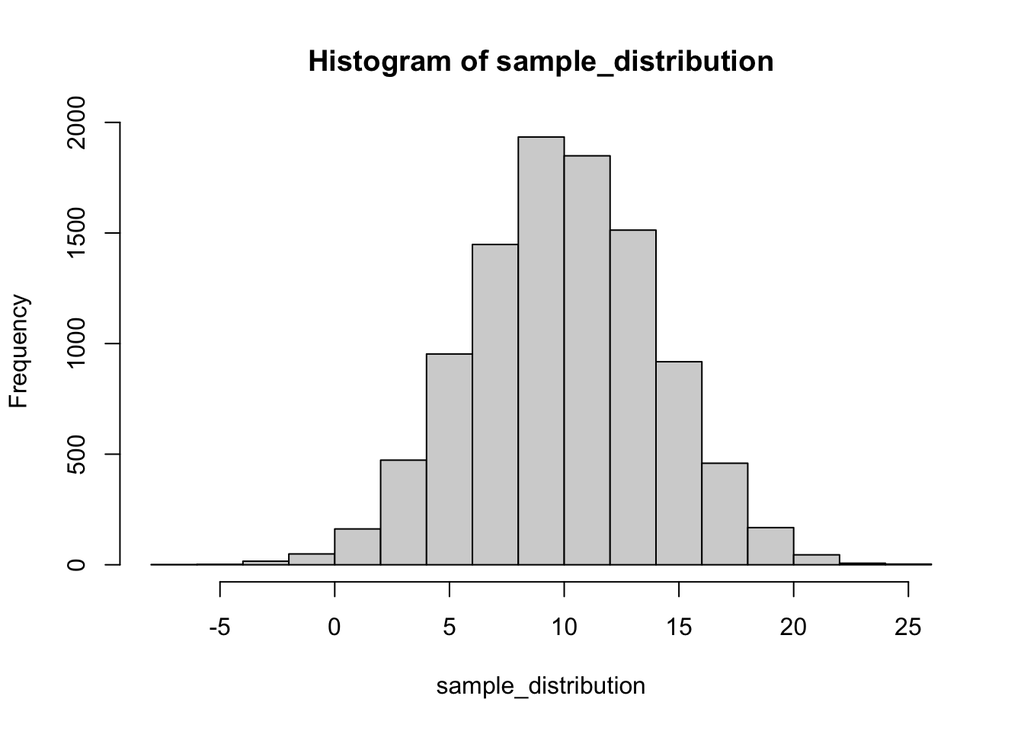

```r
## Creating a sampling distribution of the mean for this scenario with at least 10,000 sample means;


sample_distribution <- replicate(10000, mean(rnorm(25, mean = 10, sd = 20)))


hist(sample_distribution) # checking the distribution on the histogram
```

```r
# For calculating the proportion of sample means that that are 12 or larger;

length(sample_distribution[sample_distribution >= 12]) / 10000 # we used '' >='' because in the question was asked that are 12 or larger
```

```
## [1] 0.3113
```

Helping Rate : 90